# Homework 11

BMV

4/12/2018

**Question 1:**

Tree Basal Area (TBA) = (DBH/200)^2 x 3.142 m2.

Where DBH is the Diameter at Breast height (cm) and 3.142 is π

Call in the data for global variables. For this data set, I do not have a parameter that can vary.

```r
data=read.csv("/Volumes/Macintosh HD/Users/Brittany/Documents/UVM/red spruce/CHSurvey1965_2015/CH_data_1965_2015.csv", header=TRUE)

picea=subset(data, data$SPECIES==4)

picea=picea$DIAM
head(picea)
```

```
## [1]  6.6  2.5  3.3  2.0 24.4  2.5
```

```r
##################################################
# function: TreeBasalArea
# converts the diameter in cm to the basal area in m2
# input: DBH=vector of diameter of breast heights for picea
# output: TBA is a vector of basal area estimates in meters sqaured
#-------------------------------------------------
TreeBasalArea=function(DBH=picea){
  TBA=(DBH/200)^2 * 3.142
return(TBA)
}

head(TreeBasalArea())
```

```
## [1] 0.0034216380 0.0004909375 0.0008554095 0.0003142000 0.0467655280
## [6] 0.0004909375
```

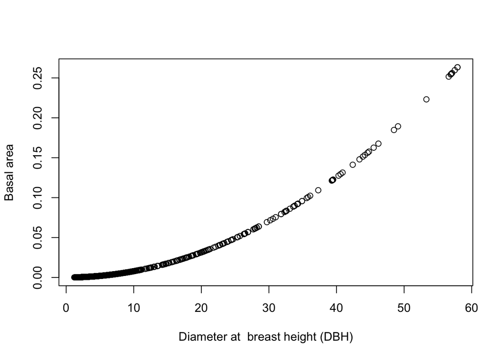

```r
##################################################
# function: BasalAreaPlot
# plot basal area
# input: DBH=vector of diameter of breast heights for picea
# output: smoothed curve with parameters in graph
#-------------------------------------------------
BasalAreaPlot <- function(DBH=picea) {
plot(x=DBH,y=TreeBasalArea(DBH),xlab="Diameter at  breast height (DBH)",ylab="Basal area")
      return()
}
BasalAreaPlot()
```

**Question 2:**

Using a different data set that contains estimates of timing of bud set for 42 trees located along elevational gradient. Looking at relationship between bud set ~ elevation.

Preliminaries

```r
library("ggplot2")
library("TeachingDemos")
char2seed("Cruel April")
```

Call in data to global environment.

```r
budset=read.csv("/Volumes/kellrlab/datashare/Spruce/Collection Data/Seeds/GerminationRound1/budset/ele_mean_budset.csv", header=TRUE)

budset=budset[,c(2,4)]
head(budset)
```

```
##   Elevation Julian_Day
## 1       912   305.5714
## 2       914   286.0000
## 3       916   299.6923
## 4       929   310.4167
## 5       933   317.8000
## 6       937   311.0000
```

Functions

```r
###################################
# Function: readData
# read in or generate data frame
# input: file name (or nothing for demo)
# output: 3-column data frame of observed data (ID, x, y)
#---------------------------------
readData <- function(z=NULL) {
  if (is.null(z)) {
    xVar <- budset$Elevation
    yVar <- budset$Julian_Day
    dF <- data.frame(ID=seq_along(xVar),xVar,yVar)
  }
  return(dF)
}
readData()
```

```
##    ID xVar     yVar
## 1   1  912 305.5714
## 2   2  914 286.0000
## 3   3  916 299.6923
## 4   4  929 310.4167
## 5   5  933 317.8000
## 6   6  937 311.0000
## 7   7  941 314.0417
## 8   8  951 312.0000
## 9   9  953 279.0000
## 10 10  996 312.8529
## 11 11 1041 306.5000
## 12 12 1066 298.1579
## 13 13 1088 279.0000
## 14 14 1091 296.0000
```

[output cut: 28 more lines]

```r
###################################
# Function: getMetric
# calculate metric for randomization test
# input: 3-column data frame for regression
# output: regression slope
#---------------------------------
getMetric <- function(z=NULL) {
  if (is.null(z)) {
    xVar <- budset$Elevation
    yVar <- budset$Julian_Day
    z <- data.frame(ID=seq_along(xVar),xVar,yVar)
  }
  . <- lm(z[,3]~z[,2])
  . <- summary(.)
  . <- .$coefficients[2,1]
  slope <- .
  return(slope)
}
getMetric()
```

```
## [1] -0.04832834
```

```r
###################################
# Function: shuffleData
# randomize data for regression analysis
# input: 3-column data frame (ID, xVar, yVar)
# output: 3-column data frame (ID, xVar, yVar)
#---------------------------------
shuffleData <- function(z=NULL) {
  if (is.null(z)) {
    xVar <- budset$Elevation
    yVar <- budset$Julian_Day
    z <- data.frame(ID=seq_along(xVar),xVar,yVar)
  }
  z[,3] <- sample(z[,3])
  return(z)
}
shuffleData()
```

```
##    ID xVar     yVar
## 1   1  912 315.0000
## 2   2  914 321.0000
## 3   3  916 309.7692
## 4   4  929 321.0000
## 5   5  933 313.9333
## 6   6  937 321.0000
## 7   7  941 319.4000
## 8   8  951 321.0000
## 9   9  953 314.2857
## 10 10  996 310.4167
## 11 11 1041 321.0000
## 12 12 1066 307.0769
## 13 13 1088 298.1579
## 14 14 1091 301.6667
```

[output cut: 28 more lines]

```r
###################################
# Function: getPVal
# calculate p value for observed, simulated data
# input: list of observed metric and vector of simulated metric
# output: lower, upper tail probability vector
#---------------------------------
getPVal <- function(z=NULL) {
  if (is.null(z)) {
    z <- list(xObs=runif(1),xSim=runif(1000))
  }
  pLower <- mean(z[[2]] <= z[[1]])
  pUpper <- mean(z[[2]] >= z[[1]])
  return(c(pL=pLower,pU=pUpper))
}
getPVal()
```

```
##    pL    pU
## 0.097 0.903
```

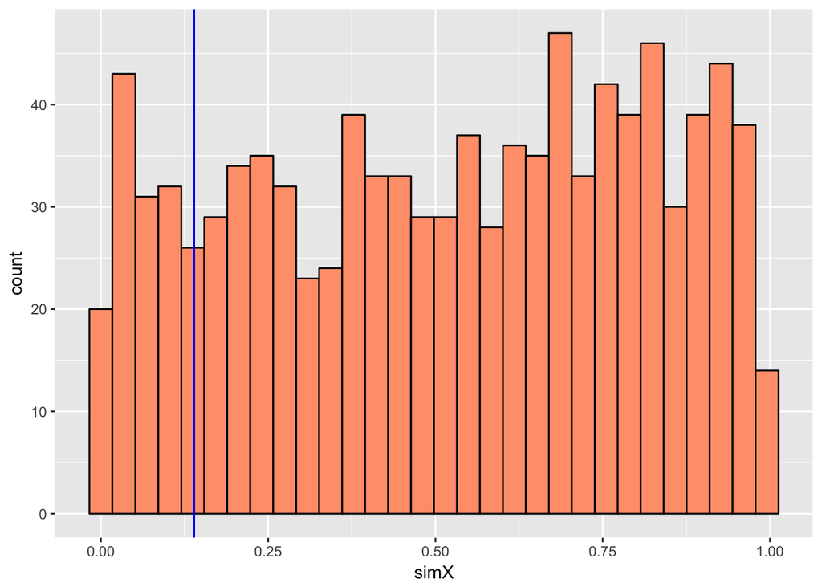

```r
###################################
# Function: plotRanTest
# ggplot graph
# input: list of observed metric and vector of simulated metric
# output: ggplot graph
#---------------------------------
plotRanTest <- function(z=NULL) {
  if (is.null(z)) {
    z <- list(xObs=runif(1),xSim=runif(1000))
  }
  dF <- data.frame(ID=seq_along(z[[2]]),simX=z[[2]])
  p1 <- ggplot(data=dF, mapping = aes(x=simX))
  p1 + geom_histogram(mapping = aes(fill=I("lightsalmon"),color=I("black"))) + geom_vline(aes(xintercept=z[[1]],col="blue"))
}
plotRanTest()
```

Main body of code

```r
nSim <- 1000 # number of simulations
XSim <- rep(NA, nSim) # will hold simulated slopes

dF <- readData()
Xobs <- getMetric(dF)

for (i in seq_len(nSim)) {
  XSim[i] <- getMetric(shuffleData(dF))
}

slopes <- list(Xobs,XSim)
getPVal(slopes)
```

```
## pL pU
##  0  1
```

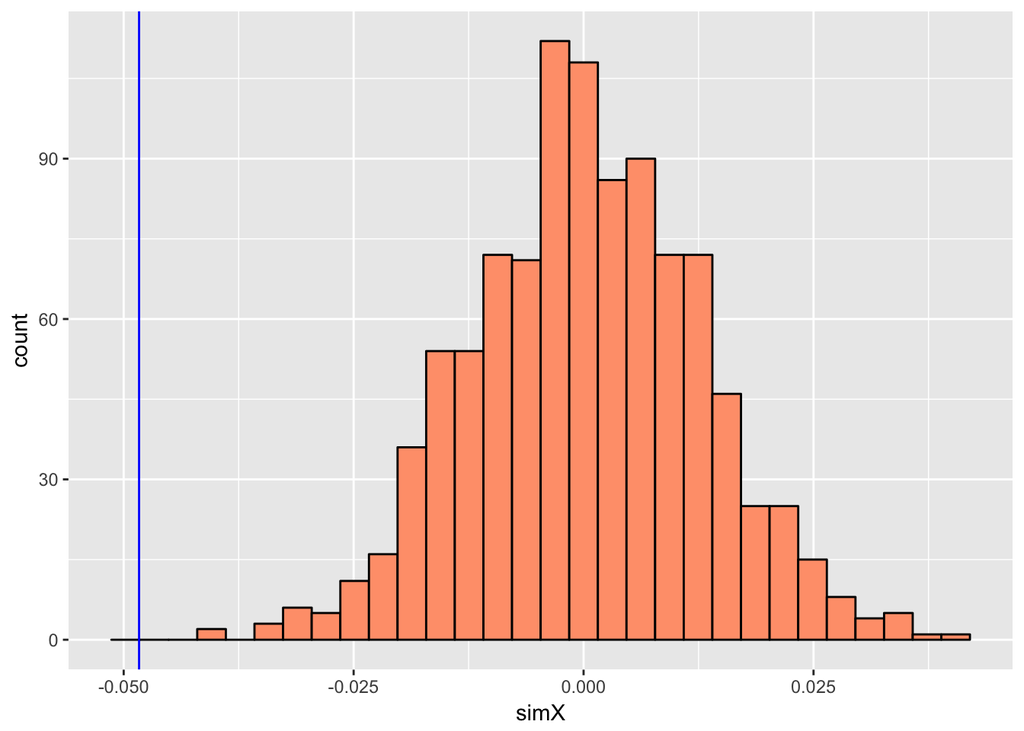

```r
plotRanTest(slopes)
```

**Question 3**

The p-values are nearly the same in both tests. I would expect a slight difference given the randomization.

```r
lmBudset <- lm(budset$Julian_Day ~ budset$Elevation, data = readData())
summary(lmBudset)
```

```
##
## Call:
## lm(formula = budset$Julian_Day ~ budset$Elevation, data = readData())
##
## Residuals:
##      Min       1Q   Median       3Q      Max
## -25.1770  -3.6082   0.5259   5.8174  12.6565
##
## Coefficients:
##                   Estimate Std. Error t value Pr(>|t|)
## (Intercept)      350.23388    8.46305  41.384  < 2e-16 ***
## budset$Elevation  -0.04833    0.01014  -4.766 2.49e-05 ***
## ---
## Signif. codes:  0 '***' 0.001 '**' 0.01 '*' 0.05 '.' 0.1 ' ' 1
##
## Residual standard error: 8.672 on 40 degrees of freedom
## Multiple R-squared:  0.3622, Adjusted R-squared:  0.3463
## F-statistic: 22.72 on 1 and 40 DF,  p-value: 2.487e-05
```

```r
lmBudsetShuffle <- lm(budset$Julian_Day ~ budset$Elevation, data = shuffleData())
summary(lmBudsetShuffle)
```

```
##
## Call:
## lm(formula = budset$Julian_Day ~ budset$Elevation, data = shuffleData())
##
## Residuals:
##      Min       1Q   Median       3Q      Max
## -25.1770  -3.6082   0.5259   5.8174  12.6565
##
## Coefficients:
##                   Estimate Std. Error t value Pr(>|t|)
## (Intercept)      350.23388    8.46305  41.384  < 2e-16 ***
## budset$Elevation  -0.04833    0.01014  -4.766 2.49e-05 ***
## ---
## Signif. codes:  0 '***' 0.001 '**' 0.01 '*' 0.05 '.' 0.1 ' ' 1
##
## Residual standard error: 8.672 on 40 degrees of freedom
## Multiple R-squared:  0.3622, Adjusted R-squared:  0.3463
## F-statistic: 22.72 on 1 and 40 DF,  p-value: 2.487e-05
```